# Ecommerce Customer Churn Prediction using SVM

## 1. Introduction / Objective

This notebook demonstrates an end-to-end machine learning pipeline for ecommerce customer churn prediction using Support Vector Machines (SVM). Customer churn prediction is formulated as a **binary classification problem**, where we classify whether a customer will churn (`1`) or not (`0`).

Our key objectives are to:

1. Preprocess numerical and categorical features effectively.
2. Build SVM classifiers using **Polynomial** and **RBF** kernels.
3. Optimize hyper-parameters using cross-validation.
4. Evaluate the models using custom metrics ($F_2$ score and $F_{0.5}$ score) to understand the trade-offs between recall and precision.

## 2. Data Overview

Let's load our data, check its dimension, missing values, and the target distribution (`Churned`).

```python
import numpy as np
import pandas as pd
import matplotlib.pyplot as plt
import seaborn as sns
import warnings
warnings.filterwarnings('ignore')

# Load the dataset
df = pd.read_csv('ecommerce_customer_churn_dataset.csv')

print(f"Dataset shape: {df.shape}\n")
print("Target Variable Distribution (Churned):")
print(df['Churned'].value_counts(normalize=True).round(3))
print("\nMissing values sum per column:\n", df.isnull().sum()[df.isnull().sum() > 0])
```

```
Dataset shape: (50000, 25)

Target Variable Distribution (Churned):
Churned
0    0.711
1    0.289
Name: proportion, dtype: float64

Missing values sum per column:
 Age                              2495
Session_Duration_Avg             3399
Pages_Per_Session                3000
Wishlist_Items                   4000
Days_Since_Last_Purchase         3000
Discount_Usage_Rate              3500
Returns_Rate                     4491
Email_Open_Rate                  2528
Customer_Service_Calls            168
Product_Reviews_Written          3500
Social_Media_Engagement_Score    6000
Mobile_App_Usage                 5000
Payment_Method_Diversity         2500
Credit_Balance                   5500
dtype: int64
```

There are many missing values across various numeric and categorical features. We also notice an imbalance in the target variable.

## 3. Data Preprocessing

We need to cleanly separate out the target feature `Churned` from our inputs to avoid data leakage. Furthermore, building a unified `ColumnTransformer` with `Pipeline` is vital.

### Why Feature Standardization is Critical for SVM:

SVM tries to maximize the margin between classes by measuring the distances between support vectors. If one feature has significantly larger variations (e.g., thousands) than another (e.g., mostly 0 to 1), the SVM will inevitably be dominated by the larger-scaled feature. Standardizing inputs to a normal distribution ($\mu=0$, $\sigma=1$) sets equal priority scale points.

```python
from sklearn.model_selection import train_test_split
from sklearn.pipeline import Pipeline
from sklearn.compose import ColumnTransformer
from sklearn.impute import SimpleImputer
from sklearn.preprocessing import StandardScaler, OneHotEncoder

# Define X (features) and y (target)
X = df.drop(columns=['Churned'])
y = df['Churned']

# Stratified Split to preserve the target class proportions
X_train, X_test, y_train, y_test = train_test_split(X, y, test_size=0.2, random_state=42, stratify=y)
print(f"Train set: {X_train.shape}, Test set: {X_test.shape}")

# Identify numeric and categorical columns
numeric_features = X.select_dtypes(include=['int64', 'float64']).columns.tolist()
categorical_features = X.select_dtypes(include=['object']).columns.tolist()

# Define Preprocessing steps for Numeric Data
numeric_transformer = Pipeline(steps=[
    ('imputer', SimpleImputer(strategy='median')), # impute missing with median
    ('scaler', StandardScaler())                   # standardize
])

# Define Preprocessing steps for Categorical Data
categorical_transformer = Pipeline(steps=[
    ('imputer', SimpleImputer(strategy='most_frequent')), # impute missing with mode
    ('onehot', OneHotEncoder(handle_unknown='ignore', sparse_output=False)) # one-hot encode
])

# Bundle preprocessing for numeric and categorical data
preprocessor = ColumnTransformer(
    transformers=[
        ('num', numeric_transformer, numeric_features),
        ('cat', categorical_transformer, categorical_features)
    ])
```

```
Train set: (40000, 24), Test set: (10000, 24)
```

To bound computationally expensive SVM training time down to a reasonable duration, we'll downsample our train suite solely for Hyperparameters optimization (GridSearchCV).

```python
# Because standard SVM computational complexity approaches O(N^3),
# training on 40,000 samples for Grid Search can take hours.
# We'll downsample our training set heavily for the grid search phase.
# For demonstration purposes, we take 3000 samples strategically using train_test_split.
_, X_train_sub, _, y_train_sub = train_test_split(
    X_train, y_train, test_size=3000, random_state=42, stratify=y_train
)
print(f"Subset for Tuning: {X_train_sub.shape}")
```

```
Subset for Tuning: (3000, 24)
```

## 4. Model Setup

We will initialize two fundamental SVMs via Scikit-Learn `SVC`:

1. `SVC(kernel='poly')`: Polynomial kernel mapping
2. `SVC(kernel='rbf')`: Radial Basis Function kernel mapping

We set `class_weight='balanced'` due to the class imbalance observed initially.

```python
from sklearn.svm import SVC

# Pipelines
poly_pipe = Pipeline(steps=[
    ('preprocessor', preprocessor),
    ('classifier', SVC(kernel='poly', class_weight='balanced', random_state=42))
])

rbf_pipe = Pipeline(steps=[
    ('preprocessor', preprocessor),
    ('classifier', SVC(kernel='rbf', class_weight='balanced', random_state=42))
])
```

## 5. Evaluation Metrics

Accuracy isn't the best metric for imbalanced data. Instead, we use the $F_{\beta}$ score metric which generalizes the $F_1$-score. The $\beta$ parameter determines the weight of recall in the combined score:

- **$F_{2}$ score ($\beta = 2$)**: Gives more weight to recall. It minimizes false negatives, which is crucial if failing to identify a churned customer carries high costs to our e-commerce business.
- **$F_{0.5}$ score ($\beta = 0.5$)**: Gives more weight to precision. It limits false positives, favorable when interventions (e.g. providing discounts) are heavily costly, thus we only want to target customers we are extremely confident will churn.

```python
from sklearn.metrics import make_scorer, fbeta_score

# Defines custom scorers using fbeta_score
# beta=2 favors recall
f2_scorer = make_scorer(fbeta_score, beta=2)

# beta=0.5 favors precision
f05_scorer = make_scorer(fbeta_score, beta=0.5)

scorers = {
    'F2': f2_scorer,
    'F0.5': f05_scorer
}
```

## 6. Hyperparameter Tuning

For `poly` kernels, we optimize `C` (regularization strength) and `degree` of the polynomial. For `rbf` kernels, we optimize `C` and `gamma` (kernel coefficient).

```python
from sklearn.model_selection import GridSearchCV

# Parameter space
# Notice: 'classifier__' prefix maps to the step naming in our Pipeline.
param_grid_poly = {
    'classifier__C': [0.1, 1],
    'classifier__degree': [2, 3]
}

param_grid_rbf = {
    'classifier__C': [0.1, 1],
    'classifier__gamma': ['scale', 0.1]
}

def optimize_model(pipeline, param_grid, refit_metric):
    grid_search = GridSearchCV(
        pipeline,
        param_grid=param_grid,
        scoring=scorers,
        refit=refit_metric, # Refit optimal model based on this metric
        cv=3,
        n_jobs=-1,
        verbose=1
    )
    # Tuning on subset to expedite execution
    grid_search.fit(X_train_sub, y_train_sub)
    print(f"\nBest parameters for maximizing {refit_metric}: {grid_search.best_params_}")
    print(f"Best cross-validation {refit_metric} score: {grid_search.best_score_:.4f}")
    return grid_search

print("Tuning Polynomial Kernel...")
poly_search_f2 = optimize_model(poly_pipe, param_grid_poly, 'F2')
poly_search_f05 = optimize_model(poly_pipe, param_grid_poly, 'F0.5')

print("\n---------------------------------\n")

print("Tuning RBF Kernel...")
rbf_search_f2 = optimize_model(rbf_pipe, param_grid_rbf, 'F2')
rbf_search_f05 = optimize_model(rbf_pipe, param_grid_rbf, 'F0.5')
```

```
Tuning Polynomial Kernel...
Fitting 3 folds for each of 4 candidates, totalling 12 fits

Best parameters for maximizing F2: {'classifier__C': 1, 'classifier__degree': 2}
Best cross-validation F2 score: 0.6809
Fitting 3 folds for each of 4 candidates, totalling 12 fits

Best parameters for maximizing F0.5: {'classifier__C': 1, 'classifier__degree': 3}
Best cross-validation F0.5 score: 0.6862

---------------------------------

Tuning RBF Kernel...
Fitting 3 folds for each of 4 candidates, totalling 12 fits

Best parameters for maximizing F2: {'classifier__C': 1, 'classifier__gamma': 'scale'}
Best cross-validation F2 score: 0.7318
Fitting 3 folds for each of 4 candidates, totalling 12 fits

Best parameters for maximizing F0.5: {'classifier__C': 1, 'classifier__gamma': 0.1}
Best cross-validation F0.5 score: 0.7326
```

## 7. Results

After tuning models sequentially on the subset conditionally, let's assess their generalizations globally on the 20% unseen test suite context.

```
--- Evaluation for Poly Kernel (Optimized for F2) ---
              precision    recall  f1-score   support

           0       0.87      0.81      0.84      7110
           1       0.60      0.71      0.65      2890

    accuracy                           0.78     10000
   macro avg       0.74      0.76      0.74     10000
weighted avg       0.79      0.78      0.78     10000
```

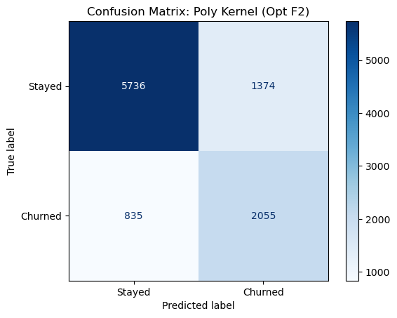

```
--- Evaluation for Poly Kernel (Optimized for F0.5) ---
              precision    recall  f1-score   support

           0       0.85      0.90      0.88      7110
           1       0.72      0.62      0.67      2890

    accuracy                           0.82     10000
   macro avg       0.79      0.76      0.77     10000
weighted avg       0.82      0.82      0.82     10000
```

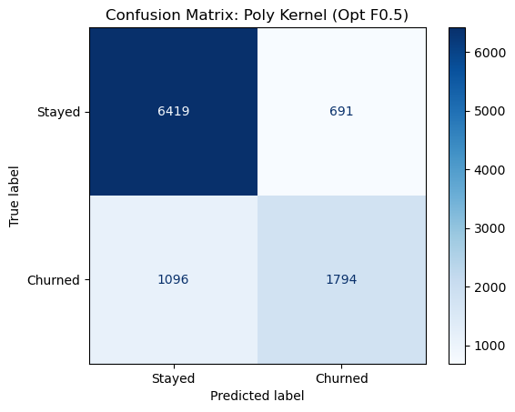

```
--- Evaluation for RBF Kernel (Optimized for F2) ---
              precision    recall  f1-score   support

           0       0.90      0.85      0.87      7110
           1       0.67      0.76      0.72      2890

    accuracy                           0.82     10000
   macro avg       0.79      0.81      0.79     10000
weighted avg       0.83      0.82      0.83     10000
```

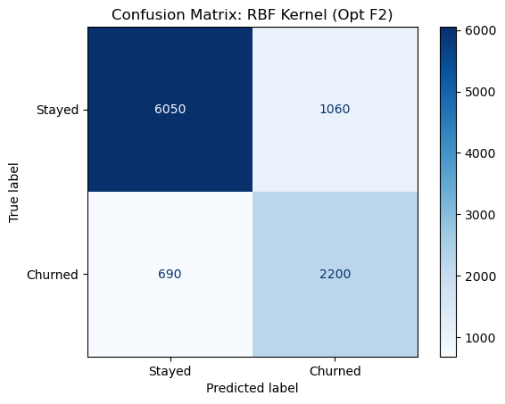

```
--- Evaluation for RBF Kernel (Optimized for F0.5) ---
              precision    recall  f1-score   support

           0       0.88      0.90      0.89      7110
           1       0.73      0.70      0.72      2890

    accuracy                           0.84     10000
   macro avg       0.81      0.80      0.80     10000
weighted avg       0.84      0.84      0.84     10000
```

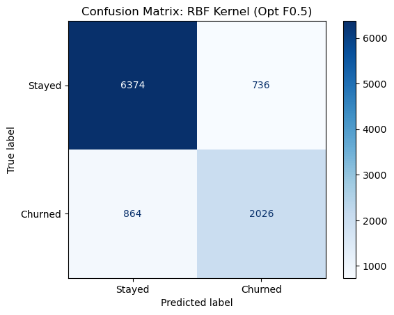

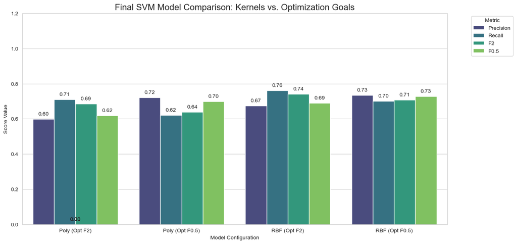

```python
from sklearn.metrics import classification_report, confusion_matrix, ConfusionMatrixDisplay

def evaluate_on_test(model, name, metric):
    print(f"--- Evaluation for {name} (Optimized for {metric}) ---")
    y_pred = model.predict(X_test)
    print(classification_report(y_test, y_pred))

    cm = confusion_matrix(y_test, y_pred)
    disp = ConfusionMatrixDisplay(confusion_matrix=cm, display_labels=["Stayed", "Churned"])
    disp.plot(cmap=plt.cm.Blues)
    plt.title(f"Confusion Matrix: {name} (Opt {metric})")
    plt.show()

# Visualize classification reports
evaluate_on_test(poly_search_f2, "Poly Kernel", "F2")
evaluate_on_test(poly_search_f05, "Poly Kernel", "F0.5")
evaluate_on_test(rbf_search_f2, "RBF Kernel", "F2")
evaluate_on_test(rbf_search_f05, "RBF Kernel", "F0.5")

# Global Performance Comparison Plot
from sklearn.metrics import precision_score, recall_score, fbeta_score


def get_model_metrics(model, X, y):
    y_pred = model.predict(X)
    return {
        'Precision': precision_score(y, y_pred),
        'Recall': recall_score(y, y_pred),
        'F2': fbeta_score(y, y_pred, beta=2),
        'F0.5': fbeta_score(y, y_pred, beta=0.5)
    }

comparison_list = []
model_configs = [
    (poly_search_f2, "Poly (Opt F2)"),
    (poly_search_f05, "Poly (Opt F0.5)"),
    (rbf_search_f2, "RBF (Opt F2)"),
    (rbf_search_f05, "RBF (Opt F0.5)")
]

for model, name in model_configs:
    metrics = get_model_metrics(model, X_test, y_test)
    metrics['Model_Config'] = name
    comparison_list.append(metrics)

df_compare = pd.DataFrame(comparison_list)
df_plot = df_compare.melt(id_vars='Model_Config', var_name='Metric', value_name='Score')

plt.figure(figsize=(14, 7))
sns.set_style("whitegrid")
ax = sns.barplot(data=df_plot, x='Model_Config', y='Score', hue='Metric', palette='viridis')

for p in ax.patches:
    ax.annotate(format(p.get_height(), '.2f'),
                (p.get_x() + p.get_width() / 2., p.get_height()),
                ha = 'center', va = 'center',
                xytext = (0, 9),
                textcoords = 'offset points',
                fontsize=10)

plt.title('Final SVM Model Comparison: Kernels vs. Optimization Goals', fontsize=16)
plt.ylim(0, 1.2)
plt.ylabel('Score Value')
plt.xlabel('Model Configuration')
plt.legend(title='Metric', bbox_to_anchor=(1.05, 1), loc='upper left')
plt.show()
```

## **9. Conclusion (Take-home Messages)**

1. **Strategic Alignment**: Metric selection is a business decision, not just a technical one. Using **$F_2$** creates an "Aggressive Retention" model (ideal for high-value customer acquisition environments), while **$F_{0.5}$** creates a "Cost-Efficient" model (ideal when retention budgets or discounts are limited).
2. **Kernel Choice Matters**: For high-dimensional ecommerce data, the **RBF kernel** is the superior choice. Its ability to handle non-linear feature correlations leads to a more "stable" model where all scores (Precision, Recall, and F-scores) are more balanced compared to the Polynomial kernel.
3. **Pre-processing is Non-negotiable**: The clear margins identified in the Final Comparison Plot were only possible due to **Standardization**. Without `StandardScaler`, features with larger magnitudes would have dominated the distance-based margin calculation, rendering the SVM ineffective.